# R Notebook

```r
library(tidyverse)
library(readr)

library(ggplot2)
```

# Insight in the economy of an Massively Multiplayer Online Role-Playing Game using the example of Guild Wars 2

## Getting started

### Acquire data

#### Guild Wars API

https://wiki.guildwars2.com/wiki/API:Main

#### Overview

Load the data from CSV. We don’t want to get that amount of data from the API again and again.

```r
dir <- getwd()
item_list_buys <- read.csv(paste(dir, "/gw2-all-buys.csv", sep = ""))
item_list_sells <- read.csv(paste(dir, "/gw2-all-sells.csv", sep = ""))
```

To get a quick impressions of the data, let’s have a look at the rough numbers.

This is how the buyer data looks like:

```r
glimpse(item_list_buys)
```

```
## Rows: 2,787
## Columns: 10
## $ name         <chr> "Sealed Package of Snowballs", "Sealed Package of Snowbal~
## $ description  <chr> "Open this package to create several snowballs that can h~
## $ type         <chr> "Consumable", "Consumable", "Consumable", "Consumable", "~
## $ rarity       <chr> "Basic", "Basic", "Basic", "Basic", "Basic", "Basic", "Ba~
## $ vendor_value <int> 0, 0, 0, 0, 0, 0, 0, 0, 0, 0, 0, 0, 0, 0, 0, 0, 0, 0, 0, ~
## $ id           <int> 24, 24, 24, 24, 24, 24, 24, 24, 24, 24, 24, 24, 24, 24, 2~
## $ icon         <chr> "https://render.guildwars2.com/file/1D05D1EE04E16E69710E1~
## $ listings     <int> 1, 4, 1, 1, 1, 4, 7, 5, 1, 3, 10, 1, 1, 1, 1, 1, 1, 1, 1,~
## $ unit_price   <int> 91, 90, 87, 85, 81, 80, 77, 76, 75, 74, 72, 68, 67, 66, 6~
## $ quantity     <int> 117, 970, 44, 186, 62, 1000, 1578, 1024, 250, 630, 2365, ~
```

The seller data has the same structure, just for all the sells.

```r
glimpse(item_list_sells)
```

```
## Rows: 17,108
## Columns: 10
## $ name         <chr> "Sealed Package of Snowballs", "Sealed Package of Snowbal~
## $ description  <chr> "Open this package to create several snowballs that can h~
## $ type         <chr> "Consumable", "Consumable", "Consumable", "Consumable", "~
## $ rarity       <chr> "Basic", "Basic", "Basic", "Basic", "Basic", "Basic", "Ba~
## $ vendor_value <int> 0, 0, 0, 0, 0, 0, 0, 0, 0, 0, 0, 0, 0, 0, 0, 0, 0, 0, 0, ~
## $ id           <int> 24, 24, 24, 24, 24, 24, 24, 24, 24, 24, 24, 24, 24, 24, 2~
## $ icon         <chr> "https://render.guildwars2.com/file/1D05D1EE04E16E69710E1~
## $ listings     <int> 1, 3, 5, 1, 2, 1, 3, 3, 2, 2, 4, 4, 1, 2, 2, 2, 2, 1, 4, ~
## $ unit_price   <int> 169, 185, 186, 187, 188, 189, 190, 191, 233, 234, 277, 27~
## $ quantity     <int> 17, 87, 25, 12, 4, 19, 7, 18, 5, 3, 39, 17, 3, 9, 2, 7, 8~
```

- Name: This is the name of the item.
- Description: Some items also have a description giving further information.
- Type: can be something like `armor`, `consumable`, `crafting material` and so on
- Rarity: There are 8 types of rarity from very common to very rare.
- Vendor_value: What a sell to a NPC dealer would yield.
- Id: Unique ID of the item.
- Icon: URL to a picture of the item
- Listings: How many players are offering this item to this price
- Unit_Price: What the player wants for this item (in copper)
- Quantity: How many offers of this items there are for this price.

Listings, Unit_Price and Quantity can be read together.

We’ll learn more about copper shortly.

Compare total items of **all** buys and sells:

```r
nrow(item_list_buys)
```

```
## [1] 2787
```

```r
nrow(item_list_sells)
```

```
## [1] 17108
```

Compare **unique** items of buys and sells:

```r
item_list_buys %>%
  select(name) %>%
  drop_na() %>%
  unique() %>%
  count() %>%
  first()
```

```
## [1] 67
```

```r
item_list_sells %>%
  select(name) %>%
  drop_na() %>%
  unique() %>%
  count() %>%
  first()
```

```
## [1] 67
```

## Currency

Just like in the real world, where 100 cents are 1 Euro, the main currency in Guild Wars, coins, are separated into three units.

There is copper, silver and gold. All those values are the same and are automatically calculated by the game.

`10.000 copper == 100 silver == 1 gold.`

So we need to divide all values by `10.000` to display the price in gold, which is good for expensive goods and when we are searching for the upper prices.

There may be occasions where it makes more sense to look for silver or even copper.

### Filter items for expensive goods and display them:

Vendor prices are so low (copper range), that they appear as nearly zero in this chart. If possible, it’s always better to sell items on the action house instead of the vendor.

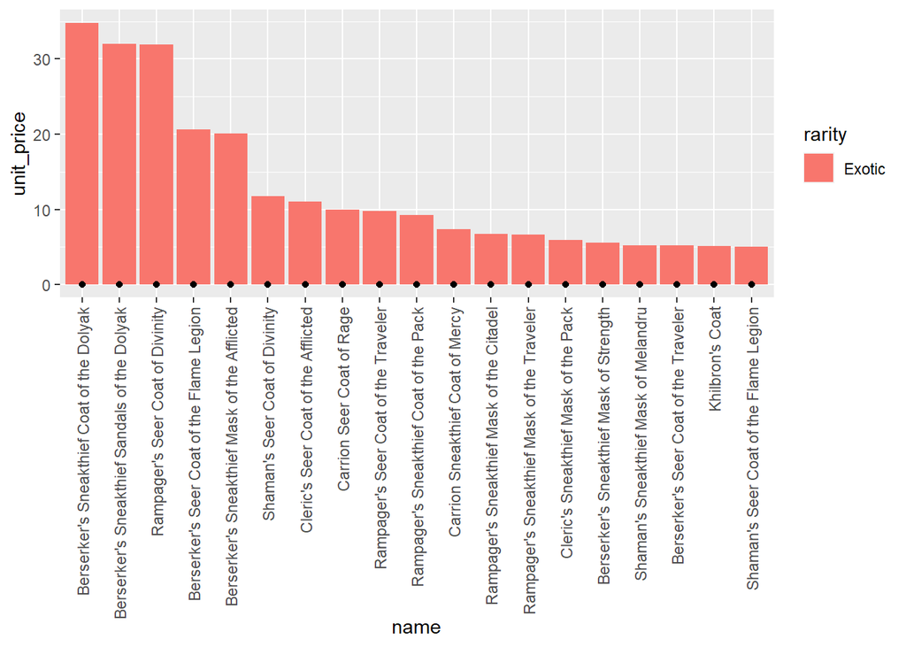

```r
item_list_sells_group <- item_list_sells %>%
  group_by(name) %>%
  summarise(unit_price = mean(unit_price) / 10000,
            vendor_value = mean(vendor_value) / 10000,
            type = unique(type),
            rarity = unique(rarity)) %>%
  filter(unit_price > 5) %>%
  arrange(desc(unit_price))

item_list_sells_group %>%
  ggplot() +
  geom_bar(aes(x = name, y = unit_price, fill = rarity), stat="identity") +
  geom_point(aes(x = name, y = vendor_value), fill = "#000000", stat="identity") +
  theme(axis.text.x = element_text(angle = 90, vjust = 0.5, hjust=1))+
  scale_x_discrete(limits = item_list_sells_group$name)
```

```r
  # geom_text(aes(label=vendor_value, x=name, y=vendor_value), hjust=0, vjust=0)
```

We’ll come back to items and their value in much more detail later.

## The rarity of items

There are different rarities in Guild Wars that suggest how often this item will occur in the game:

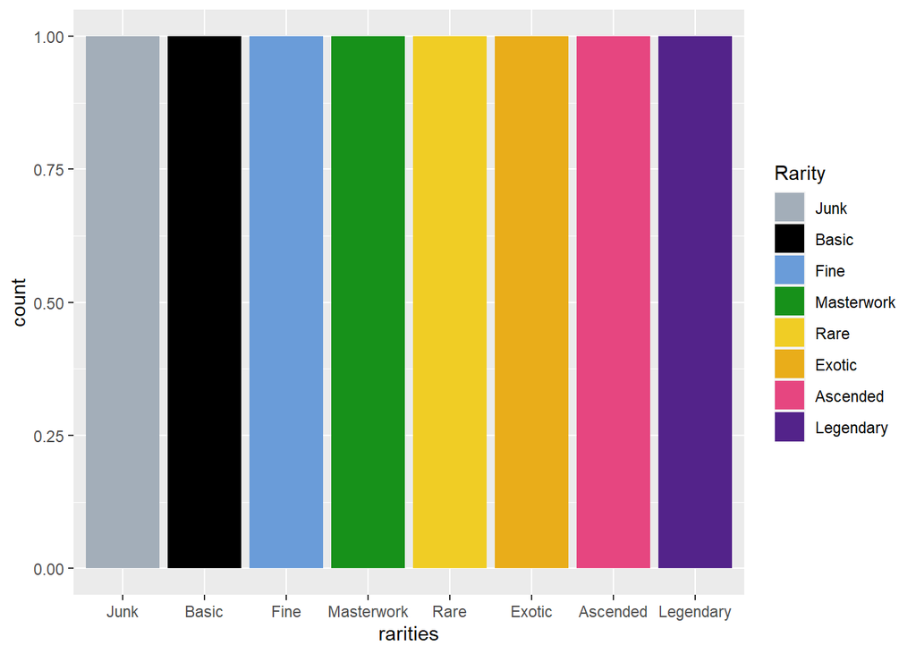

```r
rarities <-
  c("Junk", "Basic", "Fine", "Masterwork", "Rare", "Exotic", "Ascended", "Legendary")

colors <-
  c("Junk" = "#a3aeb9",
    "Basic" = "#000000",
    "Fine" = "#6a9cd9",
    "Masterwork" = "#17911a",
    "Rare" = "#f0cd25",
    "Exotic" = "#e9ad1a",
    "Ascended" = "#e64680",
    "Legendary" = "#53238a")

df <- data.frame(rarities)

df %>%
  ggplot() +
  geom_bar(aes(x = rarities, fill = rarities)) +
  scale_x_discrete(limits = rarities) +
  scale_fill_manual("Rarity", values = colors)
```

What is obvious by the names, rarity on the left is in general more common than rarity on the right.

One important information is that a lot of very rare items (`Ascended` and `Legendary`) can’t be sold to other players. That’s the reason we may see more `Rare` and `Exotic` items being sold for high prices than those really rare ones.

In our dataset, we have the following distribution:

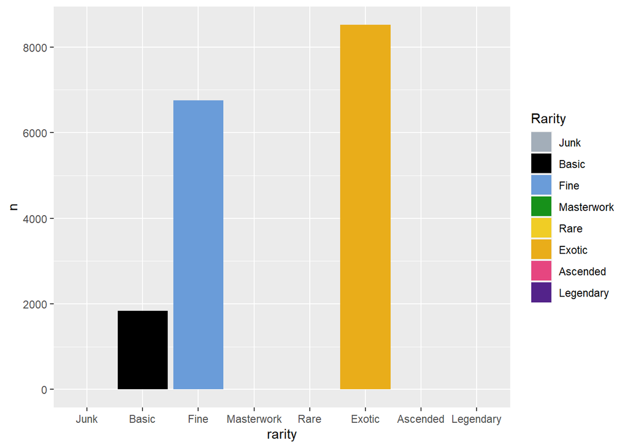

```r
df <- item_list_sells %>%
  count(rarity) %>%
  arrange(desc(n))

df %>%
  ggplot() +
  geom_bar(aes(x = rarity, y = n, fill = rarity), stat='identity') +
  scale_x_discrete(limits = rarities) +
  scale_fill_manual("Rarity", values = colors)
```

## Types

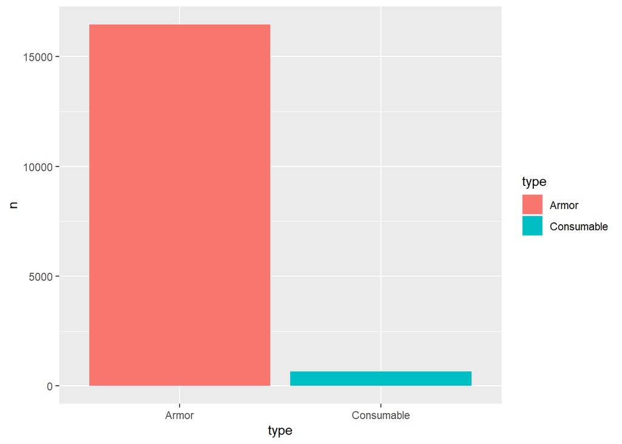

```r
df <- item_list_sells %>%
  count(type) %>%
  arrange(desc(n))

df %>%
  ggplot() +
  geom_bar(aes(x = type, y = n, fill = type), stat='identity')
```

Search for outliers:

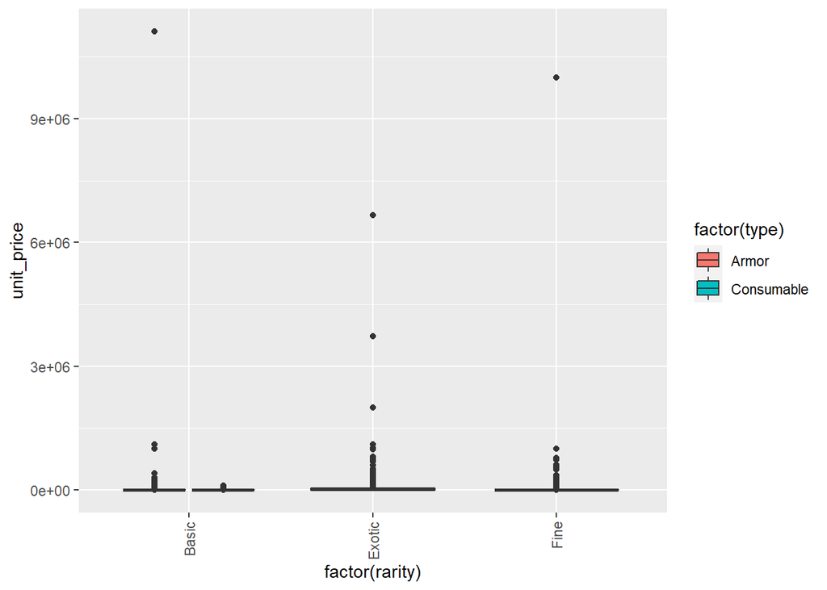

```r
# render boxplot with outliers
item_list_sells %>%
ggplot(aes(x = factor(rarity), y = unit_price, fill = factor(type))) +
  geom_boxplot() +
  theme(axis.text.x = element_text(angle = 90, vjust = 0.5, hjust=1))
```